# Personal Loan Campaign - Connie Xavier

## Problem Definition and Information

### Context

AllLife Bank is a US bank that has a growing customer base. The majority of these customers are liability customers (depositors) with varying sizes of deposits. The number of customers who are also borrowers (asset customers) is quite small, and the bank is interested in expanding this base rapidly to bring in more loan business and in the process, earn more through the interest on loans. In particular, the management wants to explore ways of converting its liability customers to personal loan customers (while retaining them as depositors). The retail marketing department wants to devise campaigns with better target marketing to increase the success ratio.

As a Data scientist at AllLife bank, I have to build a model that will help the marketing department to identify the potential customers who have a higher probability of purchasing the loan.

### Objective

To analyze, visualize, and preprocess the data, and determine the best model by building a logistic regression model and decision tree model to predict if a customer will purchase a loan.

### Key Questions

1. Is there a good model (logistic regression or decision tree) to predict whether a liability customer will buy a personal loan or not? What does the performance assessment look like for such a model?
2. What are the key factors influencing whether a liability customer will purchase a loan?
3. Which segment of customers should be targeted more?

### Data Information

Each record in the database represents a customer's information. A detailed data dictionary can be found below.

**Data Dictionary**

- ID: Customer ID
- Age: Customer’s age in completed years
- Experience: #years of professional experience
- Income: Annual income of the customer (in thousand dollars)
- ZIP Code: Home Address ZIP code.
- Family: the Family size of the customer
- CCAvg: Average spending on credit cards per month (in thousand dollars)
- Education: Education Level. 1: Undergrad; 2: Graduate;3: Advanced/Professional
- Mortgage: Value of house mortgage if any. (in thousand dollars)
- Personal_Loan: Did this customer accept the personal loan offered in the last campaign?
- Securities_Account: Does the customer have securities account with the bank?
- CD_Account: Does the customer have a certificate of deposit (CD) account with the bank?
- Online: Do customers use internet banking facilities?
- CreditCard: Does the customer use a credit card issued by any other Bank (excluding All life Bank)?

# ---------------------------------------------------------------------------------------------------------------

## Part 1: Overview of Data

```python
# import relevant libraries
# this will help in making the Python code more structured automatically (good coding practice)
%load_ext nb_black

# Library to suppress warnings or deprecation notes
import warnings

warnings.filterwarnings("ignore")

# Libraries to help with reading and manipulating data

import pandas as pd
import numpy as np

# Library to split data
from sklearn.model_selection import train_test_split

# libaries to help with data visualization
import matplotlib.pyplot as plt
import seaborn as sns

# Removes the limit for the number of displayed columns
pd.set_option("display.max_columns", None)
# Sets the limit for the number of displayed rows
pd.set_option("display.max_rows", 200)

# Libraries to build decision tree classifier
from sklearn.tree import DecisionTreeClassifier
from sklearn import tree

# To tune different models
from sklearn.model_selection import GridSearchCV

# libraries to build logist regression model
from sklearn.linear_model import LogisticRegression

# To get diferent metric scores
from sklearn.metrics import (
    f1_score,
    accuracy_score,
    recall_score,
    precision_score,
    confusion_matrix,
    ConfusionMatrixDisplay as plot_confusion_matrix,
    make_scorer,
    roc_auc_score,
    plot_confusion_matrix,
    precision_recall_curve,
    roc_curve,
)
```

```
The nb_black extension is already loaded. To reload it, use:
  %reload_ext nb_black
```

```python
# load the data
data = pd.read_csv("Loan_Modelling.csv")
```

```python
# check a sample of the data to make sure it came in correctly
data.sample(n=10, random_state=101)
```

|  | ID | Age | Experience | Income | ZIPCode | Family | CCAvg | Education | Mortgage | Personal_Loan | Securities_Account | CD_Account | Online | CreditCard |
| --- | --- | --- | --- | --- | --- | --- | --- | --- | --- | --- | --- | --- | --- | --- |
| 1718 | 1719 | 40 | 16 | 19 | 92028 | 4 | 0.4 | 2 | 0 | 0 | 0 | 0 | 1 | 1 |
| 2511 | 2512 | 51 | 27 | 92 | 92121 | 4 | 3.0 | 1 | 0 | 1 | 0 | 1 | 1 | 1 |
| 345 | 346 | 51 | 27 | 12 | 92192 | 4 | 0.5 | 2 | 78 | 0 | 1 | 0 | 1 | 0 |
| 2521 | 2522 | 49 | 23 | 29 | 94551 | 4 | 1.8 | 1 | 0 | 0 | 0 | 0 | 1 | 1 |
| 54 | 55 | 29 | 5 | 44 | 95819 | 1 | 0.2 | 3 | 0 | 0 | 0 | 0 | 1 | 0 |
| 2866 | 2867 | 46 | 22 | 141 | 90089 | 2 | 3.3 | 1 | 0 | 0 | 1 | 1 | 1 | 1 |
| 2371 | 2372 | 32 | 6 | 111 | 95014 | 2 | 1.5 | 3 | 0 | 0 | 0 | 0 | 0 | 0 |
| 2952 | 2953 | 33 | 8 | 182 | 94065 | 1 | 8.6 | 1 | 0 | 0 | 0 | 0 | 0 | 0 |
| 45 | 46 | 57 | 31 | 52 | 94720 | 4 | 2.5 | 1 | 0 | 0 | 0 | 0 | 0 | 1 |
| 4653 | 4654 | 34 | 10 | 155 | 92780 | 2 | 6.5 | 1 | 0 | 0 | 0 | 0 | 1 | 1 |

- Looks like all the features came in.
- ID appears to be unique.
- All columns appear numerical.
- No missing values shown in this sample section.

```python
# check the shape
print(f"There are {data.shape[0]} rows and {data.shape[1]} columns in the data.")
```

```
There are 5000 rows and 14 columns in the data.
```

```python
# check that the ID column is unique
data.ID.nunique()
```

```
5000
```

- Since all the values in the customer ID are unique, we can drop this column.

```python
# checking for duplicate values
data1 = data.copy()
data1 = data1.drop("ID", axis=1)
print(f"There are {data1.duplicated().sum()} duplicated rows in the data.")
```

```
There are 0 duplicated rows in the data.
```

```python
# check datatypes of the columns and which columns have null values
data1.info()
```

```
<class 'pandas.core.frame.DataFrame'>
RangeIndex: 5000 entries, 0 to 4999
Data columns (total 13 columns):
 #   Column              Non-Null Count  Dtype
---  ------              --------------  -----
 0   Age                 5000 non-null   int64
 1   Experience          5000 non-null   int64
 2   Income              5000 non-null   int64
 3   ZIPCode             5000 non-null   int64
 4   Family              5000 non-null   int64
 5   CCAvg               5000 non-null   float64
 6   Education           5000 non-null   int64
 7   Mortgage            5000 non-null   int64
 8   Personal_Loan       5000 non-null   int64
 9   Securities_Account  5000 non-null   int64
 10  CD_Account          5000 non-null   int64
 11  Online              5000 non-null   int64
 12  CreditCard          5000 non-null   int64
dtypes: float64(1), int64(12)
memory usage: 507.9 KB
```

- There are no null values as all columns have 5000 values.
- The dependent variable, Personal_Loan, is of integer type.
- All variables are numerical.
- All variables are integer type except for CCAvg which is float type.

```python
# The variables of CreditCard, Online, CD_Account, Secirities_Account, and Personal_Loan should only take on 0 or 1 values.
cols = ["Personal_Loan", "Securities_Account", "CD_Account", "Online", "CreditCard"]
for i in cols:
    print(data1[i].value_counts(normalize=True))
    print("-" * 50)
```

```
0    0.904
1    0.096
Name: Personal_Loan, dtype: float64
--------------------------------------------------
0    0.8956
1    0.1044
Name: Securities_Account, dtype: float64
--------------------------------------------------
0    0.9396
1    0.0604
Name: CD_Account, dtype: float64
--------------------------------------------------
1    0.5968
0    0.4032
Name: Online, dtype: float64
--------------------------------------------------
0    0.706
1    0.294
Name: CreditCard, dtype: float64
--------------------------------------------------
```

- The columns take on the expected 0 and 1 values.

```python
# look at the statistical summary of the data
data1.describe().T
```

|  | count | mean | std | min | 25% | 50% | 75% | max |
| --- | --- | --- | --- | --- | --- | --- | --- | --- |
| Age | 5000.0 | 45.338400 | 11.463166 | 23.0 | 35.0 | 45.0 | 55.0 | 67.0 |
| Experience | 5000.0 | 20.104600 | 11.467954 | -3.0 | 10.0 | 20.0 | 30.0 | 43.0 |
| Income | 5000.0 | 73.774200 | 46.033729 | 8.0 | 39.0 | 64.0 | 98.0 | 224.0 |
| ZIPCode | 5000.0 | 93169.257000 | 1759.455086 | 90005.0 | 91911.0 | 93437.0 | 94608.0 | 96651.0 |
| Family | 5000.0 | 2.396400 | 1.147663 | 1.0 | 1.0 | 2.0 | 3.0 | 4.0 |
| CCAvg | 5000.0 | 1.937938 | 1.747659 | 0.0 | 0.7 | 1.5 | 2.5 | 10.0 |
| Education | 5000.0 | 1.881000 | 0.839869 | 1.0 | 1.0 | 2.0 | 3.0 | 3.0 |
| Mortgage | 5000.0 | 56.498800 | 101.713802 | 0.0 | 0.0 | 0.0 | 101.0 | 635.0 |
| Personal_Loan | 5000.0 | 0.096000 | 0.294621 | 0.0 | 0.0 | 0.0 | 0.0 | 1.0 |
| Securities_Account | 5000.0 | 0.104400 | 0.305809 | 0.0 | 0.0 | 0.0 | 0.0 | 1.0 |
| CD_Account | 5000.0 | 0.060400 | 0.238250 | 0.0 | 0.0 | 0.0 | 0.0 | 1.0 |
| Online | 5000.0 | 0.596800 | 0.490589 | 0.0 | 0.0 | 1.0 | 1.0 | 1.0 |
| CreditCard | 5000.0 | 0.294000 | 0.455637 | 0.0 | 0.0 | 0.0 | 1.0 | 1.0 |

- The average age of customers is 45 years, which coincides with the median value.
- The min # of years of Experience is -3, which is unreasonable.
  - We will want to treat this value.
- There is a huge gap between the 75% and max values of Income, indicating a right-skewed distribution.
- ZipCode is a 5-digit number and they all start with 9.
  - We will see if there's any information we can extract from this variable.
- Family sizes vary from 1 to 4. It is a little surprising there are no large family sizes in the data.
- CCAvg: Some customers do not spend any money on their credit card. This variable appears to be right-skewed.
- Most customers do not have a mortgage, as the median value is 0.
- 9.6% of customers took a personal loan.
- 10.4% of customers have a securities account.
- 6% of cutomers have a CD account.
- Majority of customers use online banking services (59.6%).
- 29.4% of the customers have a credit card with another bank.

#### Feature Extraction

```python
# let's look at the ZipCode column
print(f"There are {data1.ZIPCode.nunique()} unique zip codes.")
```

```
There are 467 unique zip codes.
```

- Since there are a lot of unique zip codes, we will try to extract the sectional centers and delivery areas from the zip codes and see how many unique values there are.

```python
# check how many sectional centers and delivery areas there are
print(
    "Sectional Centers:",
    data1["ZIPCode"].astype(str).apply(lambda x: x[1:3]).nunique(),
)  # the second two numbers of a zip code is the sectional center

print(
    "Delivery Areas:", data1["ZIPCode"].astype(str).apply(lambda x: x[3:5]).nunique()
)  # the last two numbers of a zip code is the delivery area

print(
    "Sectional Centers/Delivery Areas:",
    data1["ZIPCode"].astype(str).apply(lambda x: x[1:5]).nunique(),
)
```

```
Sectional Centers: 57
Delivery Areas: 96
Sectional Centers/Delivery Areas: 467
```

- There are a lot of unique sectional centers + delivery areas.
- We will extract County information from the zip code and see how many unique values there are.

```python
# install library to extract info from zip codes
!pip install uszipcode
from uszipcode import SearchEngine
```

```python
# extract County information for each zip code
df = data1.copy()
sr = SearchEngine()
County = []
for i in df.ZIPCode:
    x = sr.by_zipcode(str(i))
    if x is None:
        County.append(
            "None"
        )  # if zip code is not found in the search engine, put "None"
    else:
        County.append(x.to_dict()["county"])
print(len(set(County)))
```

```
39
```

```python
# see how many zip codes were not found in the search engine
df["County"] = County
missing = df[df.County == "None"].ZIPCode.value_counts()
missing
```

```
92717    22
96651     6
92634     5
93077     1
Name: ZIPCode, dtype: int64
```

- These do not appear to be valid zip codes according to usps.com. We will leave these in a missing "None" category for County.

```python
# convert County to a category data type
df["County"] = df["County"].astype("category")
```

We will drop Zip Code, since we are using County information for the location.

```python
df.drop("ZIPCode", axis=1, inplace=True)
```

## Part 2: Exploratory Data Analysis

### Univariate Analysis

```python
# function to plot a boxplot and a histogram along the same scale.


def histogram_boxplot(data, feature, figsize=(12, 7), kde=True, bins=None):
    """
    Boxplot and histogram combined

    data: dataframe
    feature: dataframe column
    figsize: size of figure (default (12,7))
    kde: whether to the show density curve (default False)
    bins: number of bins for histogram (default None)
    """
    f2, (ax_box2, ax_hist2) = plt.subplots(
        nrows=2,  # Number of rows of the subplot grid= 2
        sharex=True,  # x-axis will be shared among all subplots
        gridspec_kw={"height_ratios": (0.25, 0.75)},
        figsize=figsize,
    )  # creating the 2 subplots
    sns.boxplot(
        data=data, x=feature, ax=ax_box2, showmeans=True, color="violet"
    )  # boxplot will be created and a star will indicate the mean value of the column
    sns.histplot(
        data=data, x=feature, kde=kde, ax=ax_hist2, bins=bins, palette="winter"
    ) if bins else sns.histplot(
        data=data, x=feature, kde=kde, ax=ax_hist2
    )  # For histogram
    ax_hist2.axvline(
        data[feature].mean(), color="green", linestyle="--"
    )  # Add mean to the histogram
    ax_hist2.axvline(
        data[feature].median(), color="black", linestyle="-"
    )  # Add median to the histogram
```

```python
# function to create labeled barplots


def labeled_barplot(data, feature, perc=False, n=None):
    """
    Barplot with percentage at the top

    data: dataframe
    feature: dataframe column
    perc: whether to display percentages instead of count (default is False)
    n: displays the top n category levels (default is None, i.e., display all levels)
    """

    total = len(data[feature])  # length of the column
    count = data[feature].nunique()
    if n is None:
        plt.figure(figsize=(count + 1, 5))
    else:
        plt.figure(figsize=(n + 1, 5))

    plt.xticks(rotation=90, fontsize=15)
    ax = sns.countplot(
        data=data,
        x=feature,
        palette="Paired",
        order=data[feature].value_counts().index[:n],
    )

    for p in ax.patches:
        if perc == True:
            label = "{:.1f}%".format(
                100 * p.get_height() / total
            )  # percentage of each class of the category
        else:
            label = p.get_height()  # count of each level of the category

        x = p.get_x() + p.get_width() / 2  # width of the plot
        y = p.get_height()  # height of the plot

        ax.annotate(
            label,
            (x, y),
            ha="center",
            va="center",
            size=12,
            xytext=(0, 5),
            textcoords="offset points",
        )  # annotate the percentage

    plt.show()  # show the plot
```

```
Age
```

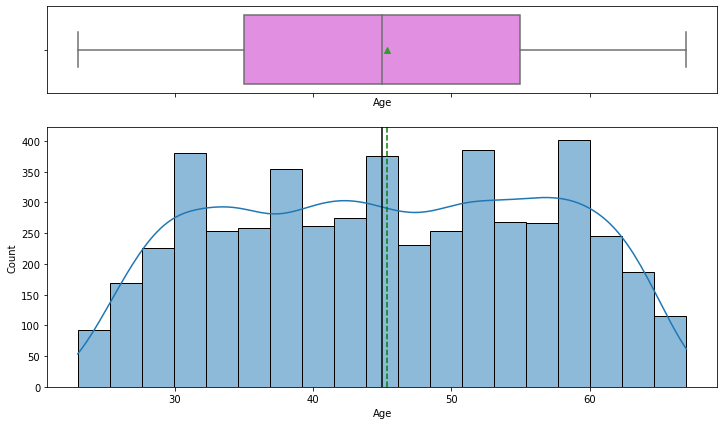

```
Experience
```

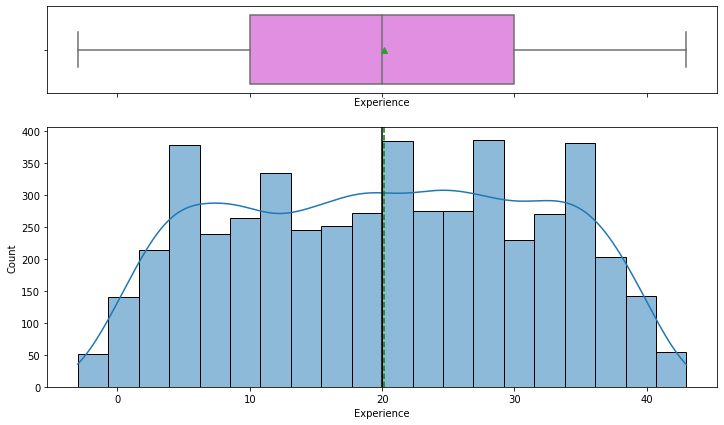

```
Income
```

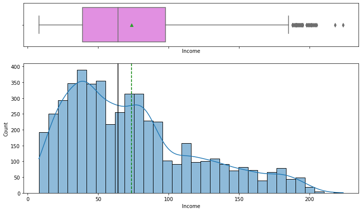

```
Family
```

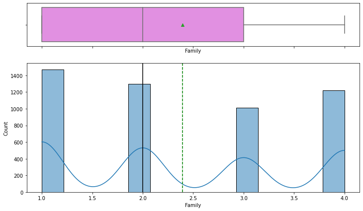

```
CCAvg
```

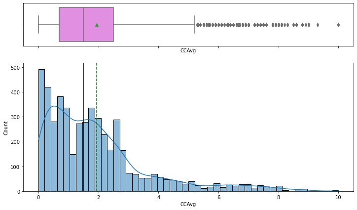

```
Education
```

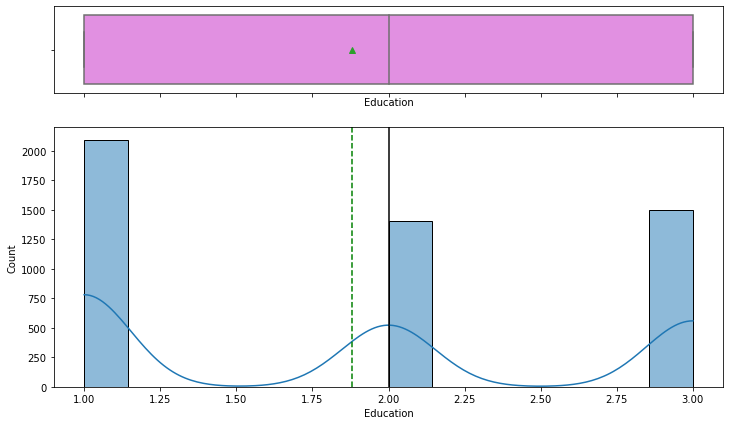

```
Mortgage
```

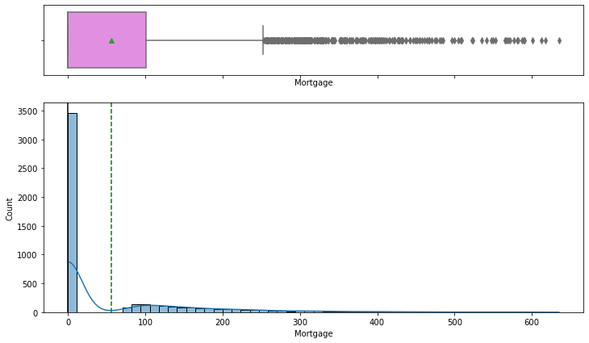

```python
## plot histogram and boxplot for the numerical features
num_cols = [
    "Age",
    "Experience",
    "Income",
    "Family",
    "CCAvg",
    "Education",
    "Mortgage",
]
for i in num_cols:
    print(i)
    histogram_boxplot(df, i)
    plt.show()
    print(
        " ****************************************************************** "
    )  ## To create a separator
```

- **Age** appears almost uniformally distributed, but with tapers on both ends. There are no outliers in age. The median and mean are close to each other.
- **Experience**: The number of years of experience appears to be distributed similarly to Age.There are some values below 0 we will need to treat.
- **Income** is right-skewed with outliers to the right, but the range is reasonable.
- **Family**: Most customers are from single-member households, with the median around 2.
- **CCAvg**: Distribution is right-skewed with outliers, but values take on a reasonable range. Customers take up to $10,000 average credit card debt.
- **Education**: Most customers have an undergrad degree, and about an equal number have graduate or advanced degrees.
- **Mortgage**: Most customers do not have a mortgage. Distribution is right-skewed with outliers. Mortgage amounts go up to ~650k which is reasonable. We will want to look at this without the 0 values to get an idea of distribution.

```
Personal_Loan
```

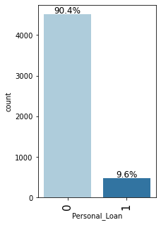

```
Securities_Account
```

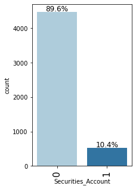

```
CD_Account
```

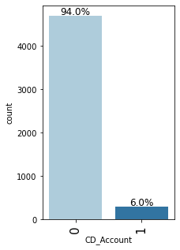

```
Online
```

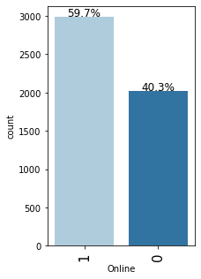

```
CreditCard
```

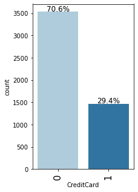

```
County
```

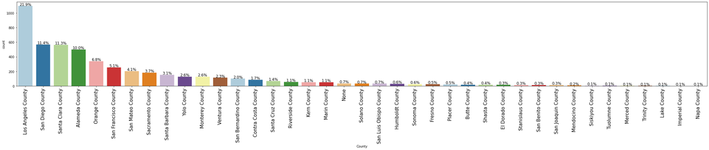

```python
## Barplot for the categorical features
cat_cols = [
    "Personal_Loan",
    "Securities_Account",
    "CD_Account",
    "Online",
    "CreditCard",
    "County",
]
for i in cat_cols:
    print(i)
    labeled_barplot(df, i, perc=True)
    plt.show()
    print(
        " ****************************************************************** "
    )  ## To create a separator
```

- Only 9.6% have bought a personal loan.
- Most customers do not have a securities account, CD account, or credict card with another bank.
- Most customers use online services.
- 21.9% of customers are from Los Angeles County.

### Bivariate Analysis

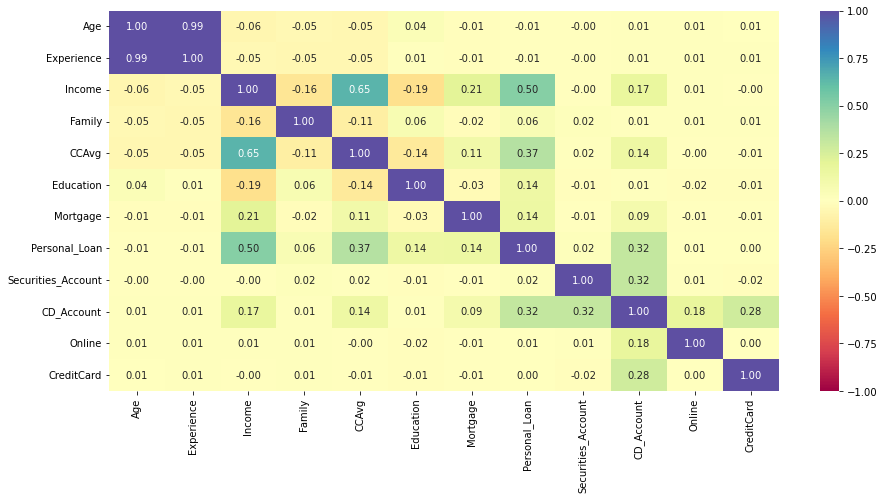

```python
# correlation plot
plt.figure(figsize=(15, 7))
sns.heatmap(df.corr(), annot=True, vmin=-1, vmax=1, fmt=".2f", cmap="Spectral")
plt.show()
```

- Experience and Age are very highly correlated, which makes sense since the distributions looked so similar. We will have to drop one of them for our logistic regression model.
- CCAvg and Income are strongly positvely correlated.
- The dependent variable, Personal_Loan, has the highest correlation with Income, followed by CCAvg.
- Income and Education are negatively correlated, which can be counterintuitive.

```python
num_cols = ["Age", "Experience", "Income", "Family", "CCAvg", "Education", "Mortgage"]
```

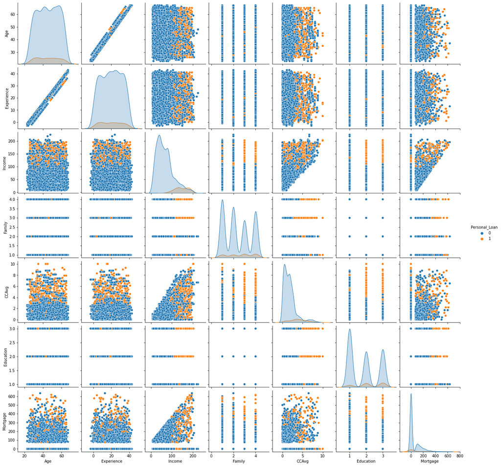

```python
sns.pairplot(data=df, hue="Personal_Loan", vars=num_cols)
plt.show()
```

- We can see some clear separations in the data for Income, CCAvg, and Mortgage with respect to Personal_Loan.
- There is a lot of overlap in the dependent variable for Age and Experience.
- The relationships for Family and Education with respect to Person_Loan will have to be looked at more closely.
- Those who accepted a personal loan cover the higher range of incomes, spending on credit cards, and mortgages.

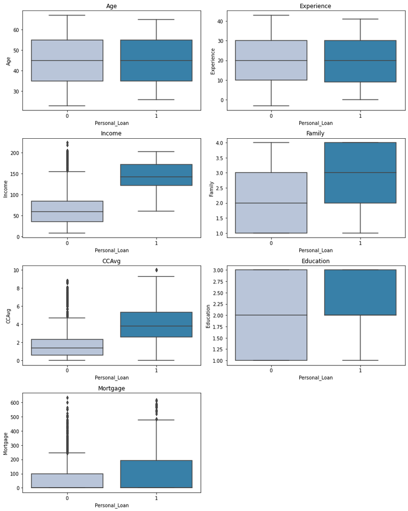

```python
# plot box plots of numerical columns separated by target variable
plt.figure(figsize=(12, 15))

for i, variable in enumerate(num_cols):
    plt.subplot(4, 2, i + 1)
    sns.boxplot(df["Personal_Loan"], df[variable], palette="PuBu")
    plt.tight_layout()
    plt.title(variable)
plt.show()
```

- Age and Experience are similar across customers who purchased a loan and those who didn't.
- Customers who purchased a loan are more likely to have higher incomes, larger families, higher average spending on credit cards, higher education levels, and mortgage.

```python
### function to plot distributions wrt target


def distribution_plot_wrt_target(data, predictor, target):

    fig, axs = plt.subplots(2, 2, figsize=(12, 10))

    target_uniq = data[target].unique()

    axs[0, 0].set_title("Distribution of target for target=" + str(target_uniq[0]))
    sns.histplot(
        data=data[data[target] == target_uniq[0]],
        x=predictor,
        kde=True,
        ax=axs[0, 0],
        color="teal",
        stat="density",
    )

    axs[0, 1].set_title("Distribution of target for target=" + str(target_uniq[1]))
    sns.histplot(
        data=data[data[target] == target_uniq[1]],
        x=predictor,
        kde=True,
        ax=axs[0, 1],
        color="orange",
        stat="density",
    )

    axs[1, 0].set_title("Boxplot w.r.t target")
    sns.boxplot(data=data, x=target, y=predictor, ax=axs[1, 0], palette="gist_rainbow")

    axs[1, 1].set_title("Boxplot (without outliers) w.r.t target")
    sns.boxplot(
        data=data,
        x=target,
        y=predictor,
        ax=axs[1, 1],
        showfliers=False,
        palette="gist_rainbow",
    )

    plt.tight_layout()
    plt.show()
```

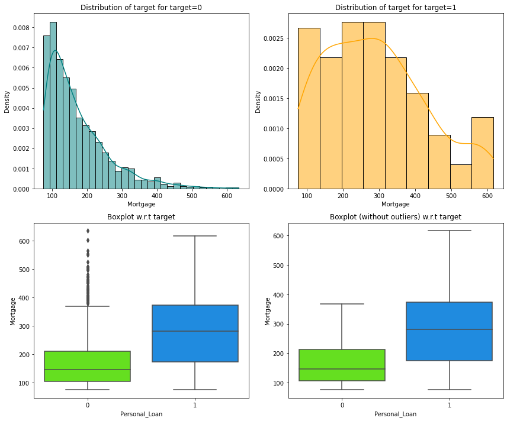

```python
# plot mortgage against Personal_Loan by removing 0 values
mort = df[df.Mortgage > 0]
distribution_plot_wrt_target(mort, "Mortgage", "Personal_Loan")
```

- After removing customers who do not have a mortgage, we get a much clearer picture of the distribution. Now, it is more obvious that customers with a larger mortgage are more likely to take a loan.

```python
# function to plot stacked bar chart


def stacked_barplot(data, predictor, target):
    """
    Print the category counts and plot a stacked bar chart

    data: dataframe
    predictor: independent variable
    target: target variable
    """
    count = data[predictor].nunique()
    sorter = data[target].value_counts().index[-1]
    tab1 = pd.crosstab(data[predictor], data[target], margins=True).sort_values(
        by=sorter, ascending=False
    )
    print(tab1)
    print("-" * 120)
    tab = pd.crosstab(data[predictor], data[target], normalize="index").sort_values(
        by=sorter, ascending=False
    )
    tab.plot(kind="bar", stacked=True, figsize=(count + 5, 6))
    plt.legend(
        loc="lower left", frameon=False,
    )
    plt.legend(loc="upper left", bbox_to_anchor=(1, 1))
    plt.show()
```

```
Securities_Account
Personal_Loan          0    1   All
Securities_Account
All                 4520  480  5000
0                   4058  420  4478
1                    462   60   522
------------------------------------------------------------------------------------------------------------------------
```

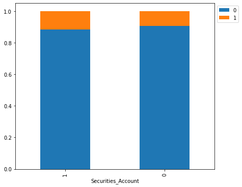

```
CD_Account
Personal_Loan     0    1   All
CD_Account
All            4520  480  5000
0              4358  340  4698
1               162  140   302
------------------------------------------------------------------------------------------------------------------------
```

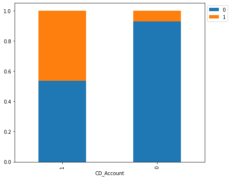

```
Online
Personal_Loan     0    1   All
Online
All            4520  480  5000
1              2693  291  2984
0              1827  189  2016
------------------------------------------------------------------------------------------------------------------------
```

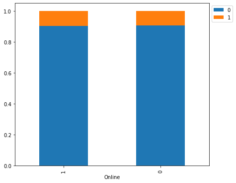

```
CreditCard
Personal_Loan     0    1   All
CreditCard
All            4520  480  5000
0              3193  337  3530
1              1327  143  1470
------------------------------------------------------------------------------------------------------------------------
```

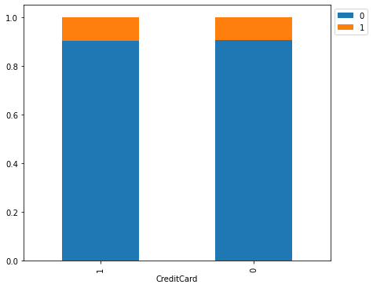

```
County
Personal_Loan              0    1   All
County
All                     4520  480  5000
Los Angeles County       984  111  1095
Santa Clara County       492   71   563
San Diego County         509   59   568
Alameda County           456   44   500
Orange County            309   30   339
San Francisco County     238   19   257
Sacramento County        169   15   184
Monterey County          113   15   128
San Mateo County         192   12   204
Contra Costa County       73   12    85
Ventura County           103   11   114
Santa Barbara County     143   11   154
Yolo County              122    8   130
Santa Cruz County         60    8    68
Kern County               47    7    54
Marin County              48    6    54
Riverside County          50    6    56
Sonoma County             22    6    28
San Luis Obispo County    28    5    33
Shasta County             15    3    18
None                      31    3    34
San Bernardino County     98    3   101
Solano County             30    3    33
Humboldt County           30    2    32
Butte County              17    2    19
Fresno County             24    2    26
Placer County             22    2    24
Stanislaus County         14    1    15
El Dorado County          16    1    17
San Joaquin County        12    1    13
Mendocino County           7    1     8
Siskiyou County            7    0     7
Imperial County            3    0     3
Napa County                3    0     3
Merced County              4    0     4
Trinity County             4    0     4
Tuolumne County            7    0     7
Lake County                4    0     4
San Benito County         14    0    14
------------------------------------------------------------------------------------------------------------------------
```

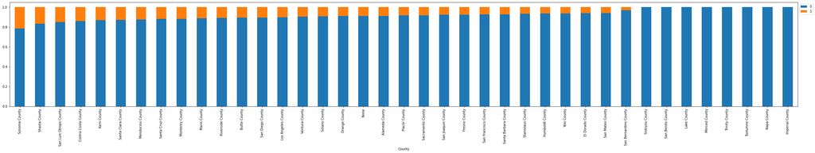

```python
# plot bar plots to determine % of target variable for each category
cat_cols = [
    "Securities_Account",
    "CD_Account",
    "Online",
    "CreditCard",
    "County",
]
for i in cat_cols:
    print(i)
    stacked_barplot(df, i, "Personal_Loan")
    plt.show()
    print(
        " ****************************************************************** "
    )  ## To create a separator
```

- Customers with a securities account are slightly more likely to take a loan.
- Customers with a CD account are much more likely to take a loan.
- Using online banking services or having a credit card at another bank is not a significant variable to determine whether a customer takes a loan.
- Customers from Sonoma or Shasta County are more likely to take a loan. Some counties do not have any customers who took a loan. This is likely do to a low number of customers from these counties.

```
Personal_Loan     0    1   All
Family
All            4520  480  5000
4              1088  134  1222
3               877  133  1010
1              1365  107  1472
2              1190  106  1296
------------------------------------------------------------------------------------------------------------------------
```

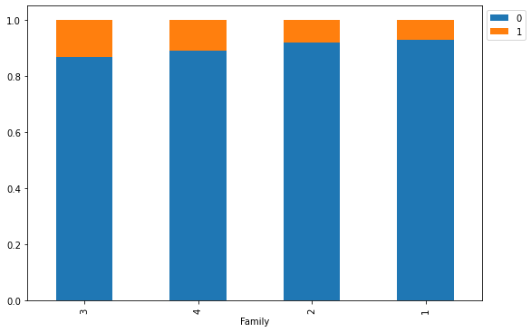

```python
# find % of target variable for Family
stacked_barplot(df, "Family", "Personal_Loan")
```

```
Personal_Loan     0    1   All
Education
All            4520  480  5000
3              1296  205  1501
2              1221  182  1403
1              2003   93  2096
------------------------------------------------------------------------------------------------------------------------
```

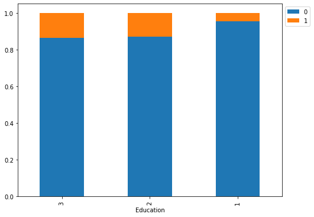

```python
# find % of target variable for Education
stacked_barplot(df, "Education", "Personal_Loan")
```

- The plots above confirm prior observations that customers who take a loan are more likely to be higher educated (graduate or advanced degree) and have larger families (3-4 members).

Let's look more closely at the categorical variables which did not appear to be a significant indicator on whether or not a customer took a loan. We will plot these against different numerical variables.

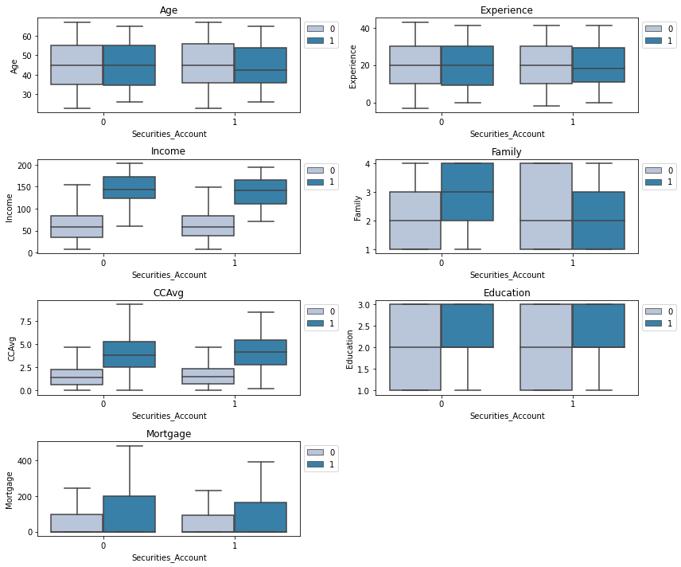

```python
# see how Securities_Account varies with other variables
cols = df[
    ["Age", "Experience", "Income", "Family", "CCAvg", "Education", "Mortgage",]
].columns.tolist()
plt.figure(figsize=(12, 10))

for i, variable in enumerate(cols):
    plt.subplot(4, 2, i + 1)
    sns.boxplot(
        df["Securities_Account"],
        df[variable],
        hue=df["Personal_Loan"],
        palette="PuBu",
        showfliers=False,  # turning-off outliers
    )
    plt.tight_layout()
    plt.legend(loc="upper left", bbox_to_anchor=(1, 1))
    plt.title(variable)
plt.show()
```

- The distributions are similar for those who do and do not have a Securities account with respect to taking a personal loan, except for Family and Mortgage.

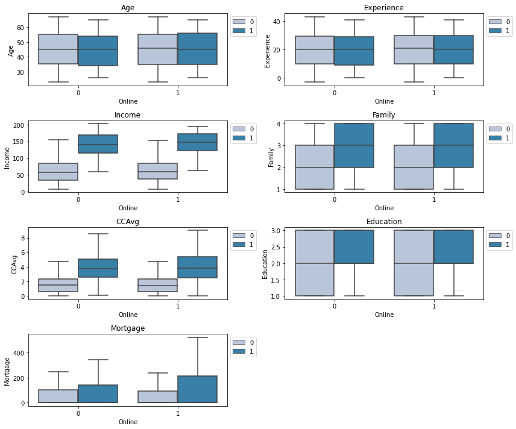

```python
# see how Online varies with other variables
plt.figure(figsize=(12, 10))

for i, variable in enumerate(cols):
    plt.subplot(4, 2, i + 1)
    sns.boxplot(
        df["Online"],
        df[variable],
        hue=df["Personal_Loan"],
        palette="PuBu",
        showfliers=False,  # turning-off outliers
    )
    plt.tight_layout()
    plt.legend(loc="upper left", bbox_to_anchor=(1, 1))
    plt.title(variable)
plt.show()
```

- The biggest difference is found when plotted against Mortgage. Customers that took a loan and used online banking services took out higher value mortgages than those that did not use online services.

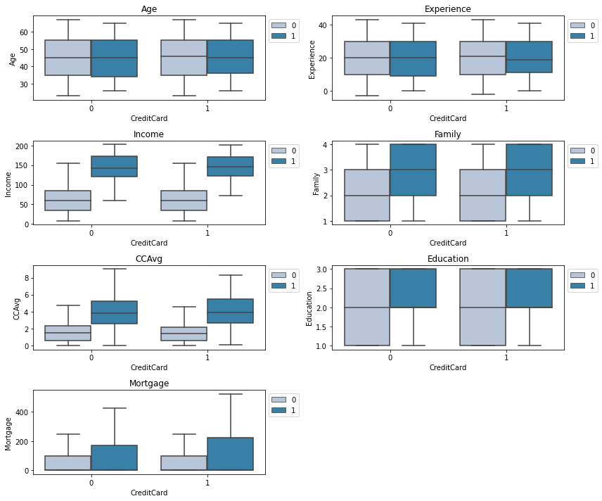

```python
# see how CreditCard varies with other variables
plt.figure(figsize=(12, 10))

for i, variable in enumerate(cols):
    plt.subplot(4, 2, i + 1)
    sns.boxplot(
        df["CreditCard"],
        df[variable],
        hue=df["Personal_Loan"],
        palette="PuBu",
        showfliers=False,  # turning-off outliers
    )
    plt.tight_layout()
    plt.legend(loc="upper left", bbox_to_anchor=(1, 1))
    plt.title(variable)
plt.show()
```

- When plotted against other numerical variables, having or not having a credit card showed similar distributions with respect to taking a loan or not.
- The biggest difference is found when plotted against Mortgage. Customers that took a loan and had a credit card with another bank took out higher value mortgages than those that did not have a credit card with another bank.

```python
# check outliers in Income
df.sort_values(by="Income", ascending=False).head(5)
```

|  | Age | Experience | Income | Family | CCAvg | Education | Mortgage | Personal_Loan | Securities_Account | CD_Account | Online | CreditCard | County |
| --- | --- | --- | --- | --- | --- | --- | --- | --- | --- | --- | --- | --- | --- |
| 3896 | 48 | 24 | 224 | 2 | 6.67 | 1 | 0 | 0 | 0 | 1 | 1 | 1 | Monterey County |
| 4993 | 45 | 21 | 218 | 2 | 6.67 | 1 | 0 | 0 | 0 | 0 | 1 | 0 | Los Angeles County |
| 526 | 26 | 2 | 205 | 1 | 6.33 | 1 | 271 | 0 | 0 | 0 | 0 | 1 | Santa Barbara County |
| 2988 | 46 | 21 | 205 | 2 | 8.80 | 1 | 181 | 0 | 1 | 0 | 1 | 0 | El Dorado County |
| 4225 | 43 | 18 | 204 | 2 | 8.80 | 1 | 0 | 0 | 0 | 0 | 1 | 0 | San Diego County |

- The two highest income values appear to be valid after looking at the other data points like Age. The Income data points are also not too far from the next highest values, so we will keep these points.

## Part 3: Data Preprocessing

- There are no missing values in the data, except for the County column, which we will keep as a separate category.
- There were some negative values in Experience, but since this is highly correlated to Age, we will drop the Experience column. Although collinearity does not affect the Decision Tree model, dropping this will help understand the important variables.

```python
# drop the highly correlated columns
df1 = df.copy()
df1.drop(["Experience"], axis=1, inplace=True)
```

## Model evaluation criterion

### Model can make wrong predictions as:

1. Predicting a customer will take a loan but in reality the customer would not take a loan. - Loss of resources
2. Predicting a customer will not take a loan but in reality the customer would have taken a loan. - Loss of opportunity

### Which case is more important?

- Predicting a customer who would have taken a loan as someone who would not, would be more detrimental to the business.

### How to reduce this loss?

- `recall` should be maximized, the greater the recall higher the chances of minimizing the false negatives.

## Part 4: Logistic Regression Model Building

```python
# standardize continuous features that are normally distributed for the logistic regression model
df_lr = df1.copy()  # lr stands for logistic regression
from sklearn.preprocessing import StandardScaler

std_scaler = StandardScaler()

std_cols = ["Age", "Income", "CCAvg", "Mortgage"]
for col in std_cols:
    df_lr[col + "_std"] = std_scaler.fit_transform(df_lr[[col]])

df_lr.drop(std_cols, axis=1, inplace=True)

# treat Education as a categorical variable
df_lr[["Education"]] = df_lr[["Education"]].astype("category")

# We will drop County as it causes test and training results to vary more
df_lr.drop(["County"], axis=1, inplace=True)
```

```python
# create X and Y variables
X = df_lr.drop(["Personal_Loan"], axis=1)
Y = df_lr["Personal_Loan"]

# get dummy variables
X = pd.get_dummies(X, drop_first=True)

# Splitting data in train and test sets
X_train, X_test, y_train, y_test = train_test_split(
    X, Y, test_size=0.30, random_state=101, stratify=Y
)
```

```python
# verify that training and test sets have same distribution of 0s and 1s
print("Shape of Training set : ", X_train.shape)
print("Shape of test set : ", X_test.shape)
print("Percentage of classes in training set:")
print(y_train.value_counts(normalize=True))
print("Percentage of classes in test set:")
print(y_test.value_counts(normalize=True))
```

```
Shape of Training set :  (3500, 11)
Shape of test set :  (1500, 11)
Percentage of classes in training set:
0    0.904
1    0.096
Name: Personal_Loan, dtype: float64
Percentage of classes in test set:
0    0.904
1    0.096
Name: Personal_Loan, dtype: float64
```

- Training and test data have same splits in the dependent variable.

```python
# defining a function to compute different metrics to check performance of a classification model built using sklearn


def model_performance_classification_sklearn_with_threshold(
    model, predictors, target, threshold=0.5
):
    """
    Function to compute different metrics, based on the threshold specified, to check classification model performance

    model: classifier
    predictors: independent variables
    target: dependent variable
    threshold: threshold for classifying the observation as class 1
    """

    # predicting using the independent variables
    pred_prob = model.predict_proba(predictors)[
        :, 1
    ]  # gives class probabilities. indexing takes the probabilities for class 1 only
    pred_thres = pred_prob > threshold  # gives True or False
    pred = np.round(pred_thres)  # rounds True to 1 and False to 0

    acc = accuracy_score(target, pred)  # to compute Accuracy
    recall = recall_score(target, pred)  # to compute Recall
    precision = precision_score(target, pred)  # to compute Precision
    f1 = f1_score(target, pred)  # to compute F1-score

    # creating a dataframe of metrics
    df_perf = pd.DataFrame(
        {"Accuracy": acc, "Recall": recall, "Precision": precision, "F1": f1,},
        index=[0],
    )

    return df_perf
```

```python
# defining a function to plot the confusion_matrix of a classification model built using sklearn
def confusion_matrix_sklearn_with_threshold(model, predictors, target, threshold=0.5):
    """
    To plot the confusion_matrix, based on the threshold specified, with percentages

    model: classifier
    predictors: independent variables
    target: dependent variable
    threshold: threshold for classifying the observation as class 1
    """
    pred_prob = model.predict_proba(predictors)[:, 1]
    pred_thres = pred_prob > threshold
    y_pred = np.round(pred_thres)

    cm = confusion_matrix(target, y_pred)
    labels = np.asarray(
        [
            ["{0:0.0f}".format(item) + "\n{0:.2%}".format(item / cm.flatten().sum())]
            for item in cm.flatten()
        ]
    ).reshape(
        2, 2
    )  # prints the number and the % belonging to each category in the confusion matrix

    plt.figure(figsize=(6, 4))
    sns.heatmap(cm, annot=labels, fmt="")
    plt.ylabel("True label")
    plt.xlabel("Predicted label")
```

```python
# build a basic model
model = LogisticRegression(solver="newton-cg", random_state=101)
lg = model.fit(X_train, y_train)
```

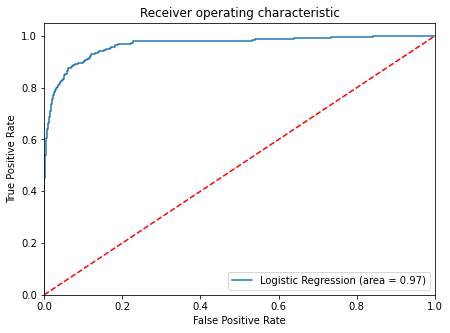

```python
# plot ROC-AUC curve for training data
logit_roc_auc_train = roc_auc_score(y_train, lg.predict_proba(X_train)[:, 1])
fpr, tpr, thresholds = roc_curve(y_train, lg.predict_proba(X_train)[:, 1])
plt.figure(figsize=(7, 5))
plt.plot(fpr, tpr, label="Logistic Regression (area = %0.2f)" % logit_roc_auc_train)
plt.plot([0, 1], [0, 1], "r--")
plt.xlim([0.0, 1.0])
plt.ylim([0.0, 1.05])
plt.xlabel("False Positive Rate")
plt.ylabel("True Positive Rate")
plt.title("Receiver operating characteristic")
plt.legend(loc="lower right")
plt.show()
```

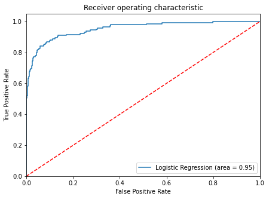

```python
# plot ROC-AUC curve for test data
logit_roc_auc_test = roc_auc_score(y_test, lg.predict_proba(X_test)[:, 1])
fpr, tpr, thresholds = roc_curve(y_test, lg.predict_proba(X_test)[:, 1])
plt.figure(figsize=(7, 5))
plt.plot(fpr, tpr, label="Logistic Regression (area = %0.2f)" % logit_roc_auc_test)
plt.plot([0, 1], [0, 1], "r--")
plt.xlim([0.0, 1.0])
plt.ylim([0.0, 1.05])
plt.xlabel("False Positive Rate")
plt.ylabel("True Positive Rate")
plt.title("Receiver operating characteristic")
plt.legend(loc="lower right")
plt.show()
```

- The model is giving a generalized performance on the training and test set.

```
Training performance:
```

|  | Accuracy | Recall | Precision | F1 |
| --- | --- | --- | --- | --- |
| 0 | 0.957714 | 0.66369 | 0.864341 | 0.750842 |

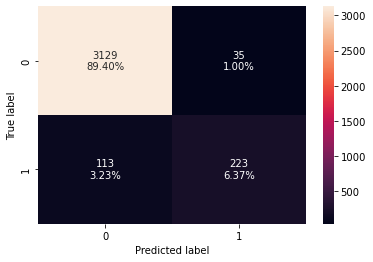

```python
# training set performance
log_reg_model_train_perf = model_performance_classification_sklearn_with_threshold(
    lg, X_train, y_train
)
# creating confusion matrix
confusion_matrix_sklearn_with_threshold(lg, X_train, y_train)
print("Training performance:")
log_reg_model_train_perf
```

```
Test performance:
```

|  | Accuracy | Recall | Precision | F1 |
| --- | --- | --- | --- | --- |
| 0 | 0.957333 | 0.645833 | 0.877358 | 0.744 |

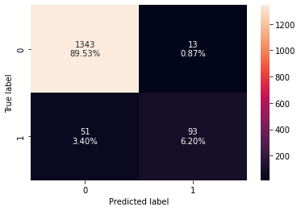

```python
# test set performance
log_reg_model_test_perf = model_performance_classification_sklearn_with_threshold(
    lg, X_test, y_test
)
# creating confusion matrix
confusion_matrix_sklearn_with_threshold(lg, X_test, y_test)
print("Test performance:")
log_reg_model_test_perf
```

- The model is giving high accuracy but low recall.
- Let's see if the recall score can be improved further, by changing the model threshold using AUC-ROC Curve.

```python
# Optimal threshold as per AUC-ROC curve
# The optimal cut off would be where tpr is high and fpr is low
fpr, tpr, thresholds = roc_curve(y_train, lg.predict_proba(X_train)[:, 1])

optimal_idx = np.argmax(tpr - fpr)
optimal_threshold_auc_roc = thresholds[optimal_idx]
print(optimal_threshold_auc_roc)
```

```
0.13882330365030518
```